# Zerene 2018 Exploratory analysis

Fernando Rodriguez

June 22, 2018

```r
# Set up ..............................................................

setwd('/home/fernando/Documents/Projects/Zerene2018/analysis/exploratory_analysis_04/')
library(ggplot2)
library(DESeq2)
library(tidyr)
library(dplyr)
library(limma)
library(pheatmap)
library(preprocessCore)

# Define functions .........................................................................

ArrangeEdata <- function(edata,pdata){  experiment <- row.names(pdata)
                                        edata.h <- data.frame(t(as.matrix(edata)))
                                        edata.o <- edata.h[match(experiment, row.names(edata.h)),]
                                        edata.v <- data.frame(t(as.matrix(edata.o)))
                                        return(edata.v)
}
```

```r
# load data ................................................................................

edata    <- read.table('evigene_24865_transcript_expression.txt', header = TRUE, row.names = 1 )
pdata    <- read.table('pheno_data.txt', header = TRUE, row.names = 1 )

# Filter pdata based on edata .............................................................

pdata <- pdata[row.names(pdata) %in% colnames(edata),]

# Rearange and filter data .................................................................

pdata        <- pdata[order(pdata$group, pdata$sex),]
pdata$group  <- factor(pdata$group, levels = unique(pdata$group))
pdata$instar <- factor(pdata$instar, levels = unique(pdata$instar))
pdata$sample <- factor(row.names(pdata), levels = row.names(pdata))

edata <- ArrangeEdata(edata,pdata)
edata <- round(edata)
edata <- edata[rowMeans(edata) > 40,]
```

This report provides summarized results of an exploratory analysis performed on the gene expression data from the Zerene cesonia wing disc development RNA-seq experiment. The expression values were estimated by mapping the reads to a reference transcriptome built using the genome Zerene_cesoni_1.0. The pipeline used is shown below:

- Reads correction: After-QC v0.9.3
- Reads filtering and triming: Trimomatic v0.36
- Reads mapped to genome: Bowtie v2.3.4
- Junctions prediction: Tophat v2.1.1
- Individual transcriptome assemblies: Cufflinks v2.2.1
- Consensus transcriptome assembly: Cuffmerge v2.2.1
- Reads mapped back to transcritpome: STAR v2.5.3a
- Gene expression estimation: featureCounts v1.2.1

## Number of read reads mapped per library

The plot below shows the total number of reads that mapped back to the annotated genome from each library during the re-mapping step. The vertical black line correspond to the desired tresshold of 30 million reads. Libraries containing mor then 100M reads were randomly samplet to a size of 70M.

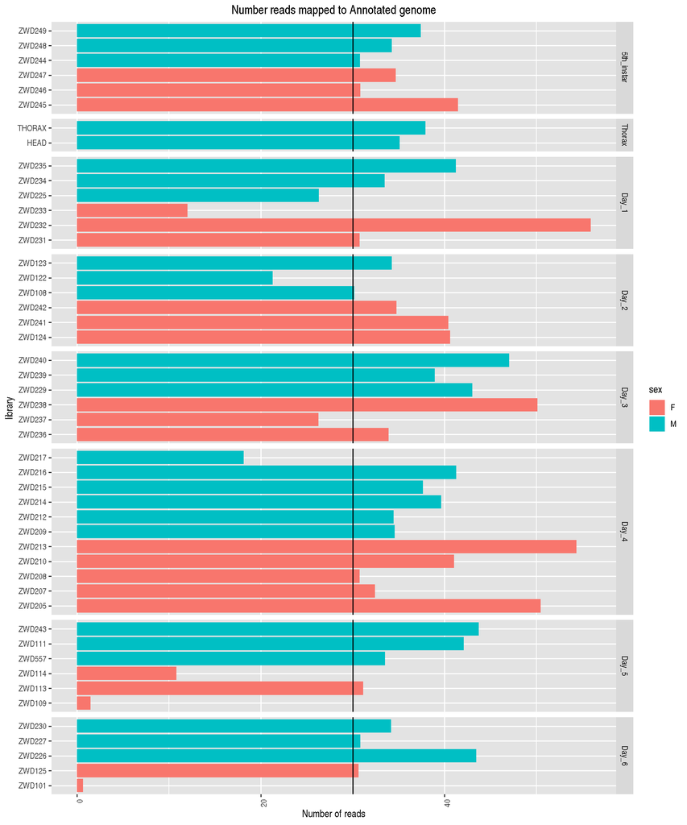

Libraries ZWD109 and ZWD101 are considered failed libraries since the number of reads mapping to the genome is too small. To prevent this technical failure from interfering with the results of the dawnstream analysis these libraries are removed from the data set. After removing these libraries a total of **1.637999710^{9}** reads were mapped to the genome in this experiment.

```r
# Remove failed librareis from data set ...............

failed <- c( 'ZWD109', 'ZWD101', 'ZWD204','HEAD','THORAX')

tr_edata <- edata[ , !names(edata) %in% failed]
pdata    <- pdata[ !row.names(pdata) %in% failed , ]
```

## Library standarization

To account for library size differences before comparing expresion profiles, a two-step normalization was performed: the **DESeq rlog** normalization and the **quantile normalization** method. The graph below shows the distribution of expression values after each normalization step.

```r
# Standarize counts for gene expression .....................................................

# Rlog normalize ......................................

tr_edata.rlog <- data.frame(rlog(as.matrix(tr_edata)))
save(tr_edata.rlog, file = './R_objects/tr_edata_rlog.rda')

  # load(file = './R_data/trans_edata_rlog.rda')
  # gn_edata.rlog <- ArrangeEdata(gn_edata.rlog,pdata)
  # tr_edata.rlog <- ArrangeEdata(tr_edata.rlog,pdata)

# Quanatile normalization .............................................

tr_edata.qn <- data.frame(normalize.quantiles(as.matrix(tr_edata.rlog)))

# Retreive column names and row names .................................

colnames(tr_edata.qn)    <- colnames(tr_edata)
row.names(tr_edata.qn)   <- row.names(tr_edata)

colnames(tr_edata.rlog)  <- colnames(tr_edata)
row.names(tr_edata.rlog) <- row.names(tr_edata)
```

```r
# Extend expressoin matrix for ploting.........................................................

raw_data  <- gather( tr_edata, 'sample', 'count' )
rlog_data <- gather( tr_edata.rlog, 'sample', 'count' )
qn_data   <- gather( tr_edata.qn, 'sample', 'count' )

# Create vector for mapping values to treatment ......................

cluster   <- c()

for(c in pdata$group){ clt <- rep(c,dim(tr_edata)[1])
                       cluster <- c(cluster, clt) }

cluster <- c(rep(cluster,3))

# concatenate data frames for ploting .................................

df <- bind_rows(as_data_frame(raw_data %>% mutate(transf = 'raw')),
                as_data_frame(rlog_data %>% mutate(transf = 'rlog')),
                as_data_frame(qn_data %>% mutate(transf = 'qn'))
)

df$transf <- factor(df$transf, levels = c('raw','rlog','qn'))
df$sample <- factor(df$sample, levels = as.vector(colnames(tr_edata)))
```

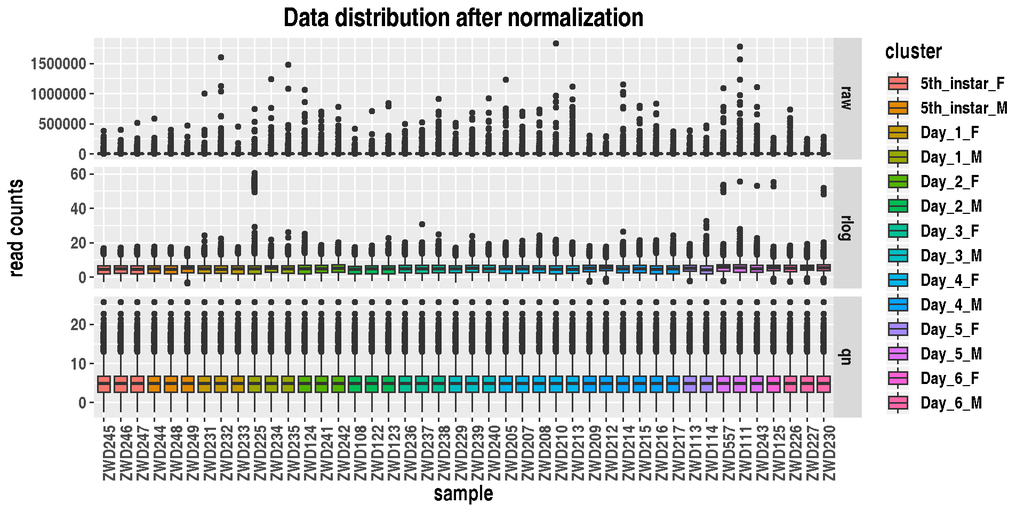

```r
# Boxplot of Raw, Rlog and quantile normalized data ......................................

ggplot(df, aes(x = sample, y = count, fill = cluster), coef = 5) +

  geom_boxplot()+
  labs(list(x='sample', y="read counts", title = 'Data distribution after normalization'))+
  theme(axis.text.x = element_text(angle = 90, hjust = 1),
        plot.title=element_text(hjust=0.5))+
  facet_grid( df$transf ~ ., scales = "free_y", shrink = FALSE)+
  theme(text = element_text(size=15, face = 'bold'))
```

### Varinace of low expressed values

The high variance of low expressed genes affects the statistics of differential expression, PCA and distance matrix. The scatter plot below shows the efficacy of each normalization method on reducing the variance of low expressed genes (bottom left) by comparing various pairs of samples.

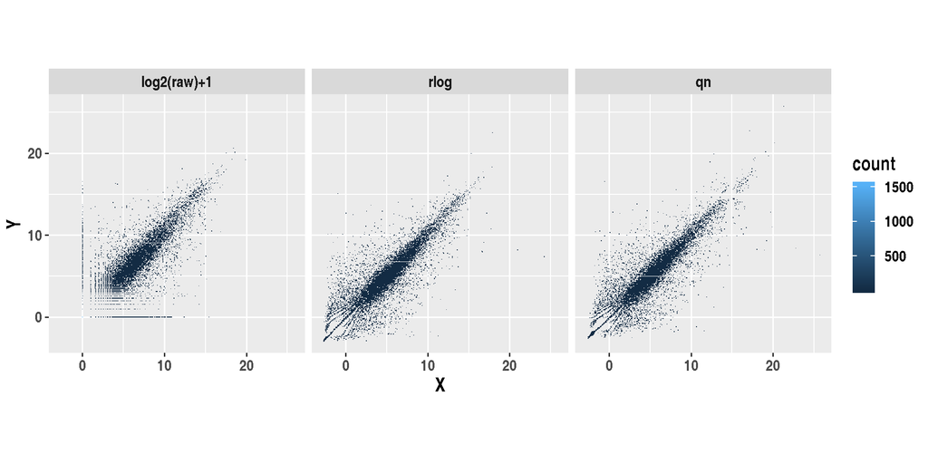

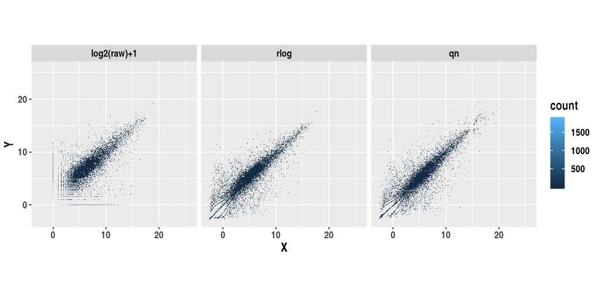

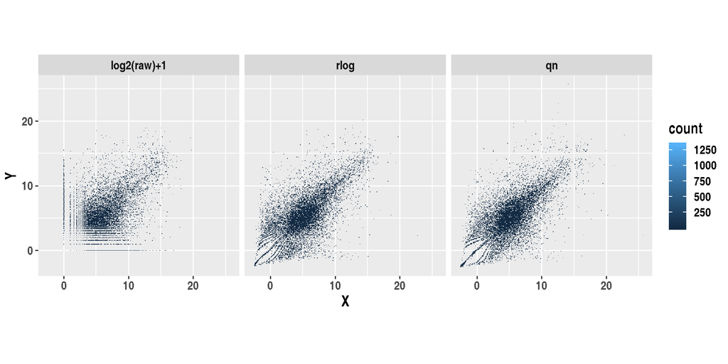

## Distance between samples and biological replicates

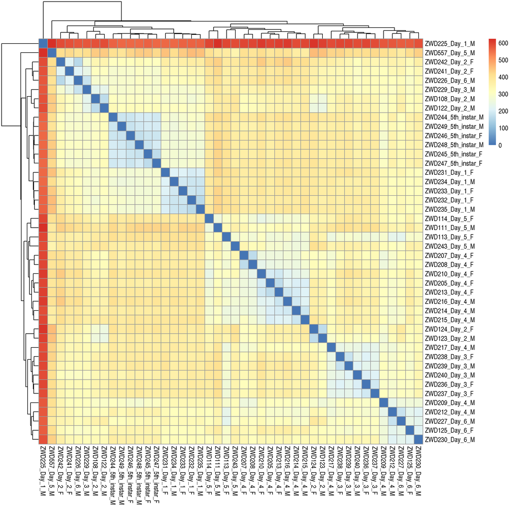

```r
# Create distance matrix for transcripts ....................

SampleDistance_tr     <- dist(t(as.matrix(tr_edata.rlog)))
SampleDistanceMatrix_tr  <- as.matrix(SampleDistance_tr)
row.names(SampleDistanceMatrix_tr)  <- as.vector(paste(pdata$sample, pdata$group, sep = '_'))
colnames(SampleDistanceMatrix_tr)  <- as.vector(paste(pdata$sample, pdata$group, sep = '_'))

# Plot distance matrix for transcripts ......................

pheatmap(SampleDistanceMatrix_tr,
         cluster_rows = SampleDistance_tr,
         cluster_cols = SampleDistance_tr)
```

### PCA plot

The Principal Components analysis cluster libraries as dots in the plot based on their resemblance. the plot below shos the result of a PCA analysis including all libraries.

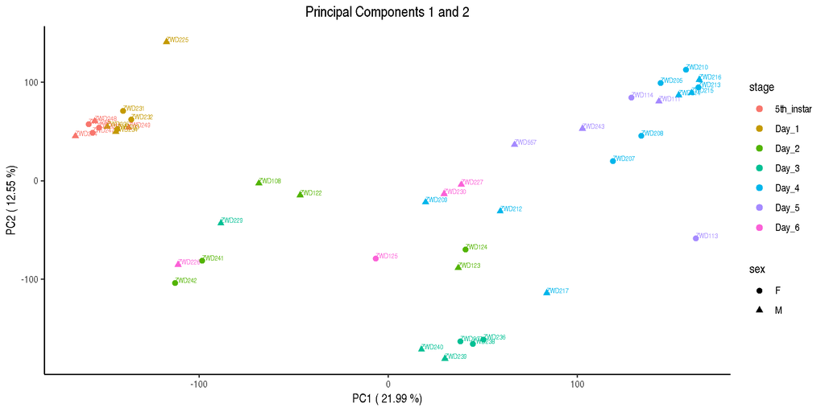

```r
# Obtain values ....................................
pca   <- prcomp(data.frame(t(as.matrix(tr_edata.rlog))))
p_var <- (pca$sdev)^2
p_ex  <- p_var / sum(p_var)
pc1   <- format(round(p_ex[1] * 100, digits = 2), nsmall = 2)
pc2   <- format(round(p_ex[2] * 100, digits = 2), nsmall = 2)

# Creade tada frame for ggplot .....................
pci <- data.frame(pca$x, stage = pdata$instar)
sex = pdata$sex

# Create plot ......................................
ggplot(pci, aes(x = PC1, y = PC2, col = stage))+
  theme_classic()+
  labs(list(x=paste('PC1 (', pc1,'%)'),
            y=paste('PC2 (',pc2,'%)'),
            title = 'Principal Components 1 and 2'))+
  theme(plot.title=element_text(hjust=0.5))+
  geom_point(size = 2, aes(shape = sex))+
  geom_text(aes(label=pdata$sample),hjust = 0, vjust = 0, size = 2)
```

## Expected differential expression

The expected patterns of differential expression between sexes for each instar is shown below. The MA-plots are built using one sample from each group (**ex.:** For day 3, only one male sample and one female sample were choosen). The samples were choosen based on similarities between library size. Each dot reprsents the difference in expression for a given gene when compared between samples. The ‘x’ axis corresponds to the sum of the expression values of that gene in both samples, and the y axis corresponds to the difference of expression values of that gene. In this graph, as x increases, genes have higher values of expresison, and as ‘y’ depart from 0 genes show increased difference of expression between samples, either positive (green) or negative (red). The reference in all graphs is male, therefore green corresponds to genes that are highly expressed in males compared to females.

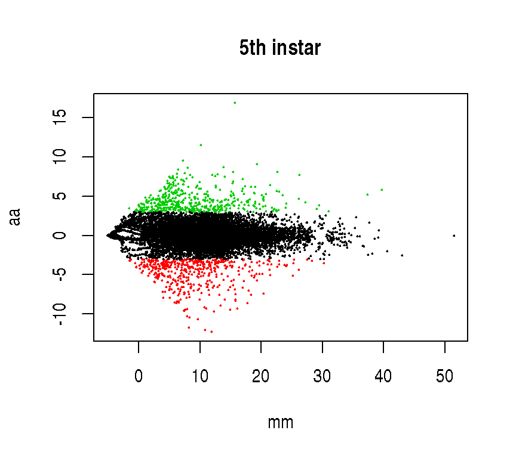

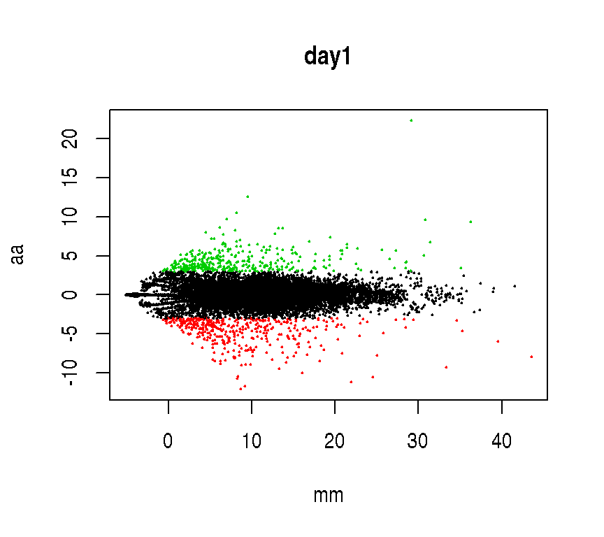

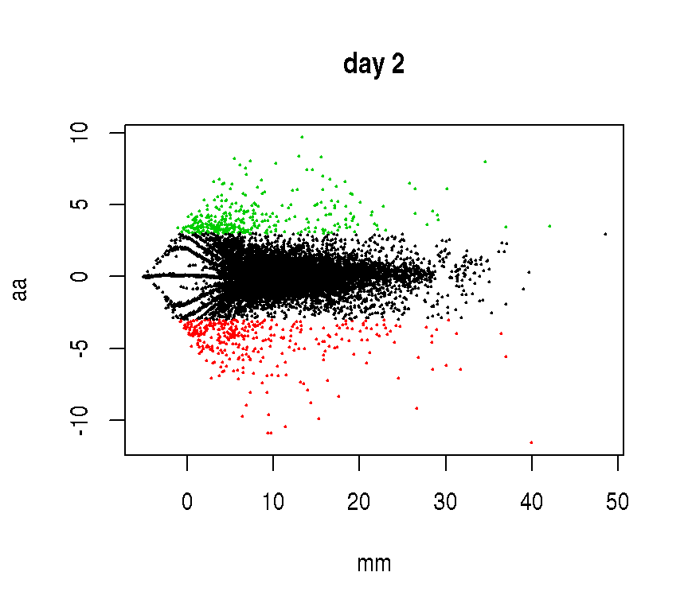

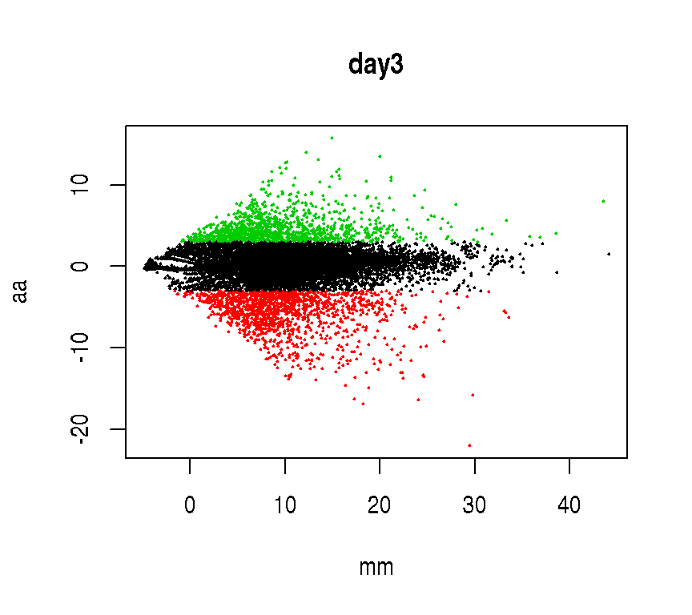

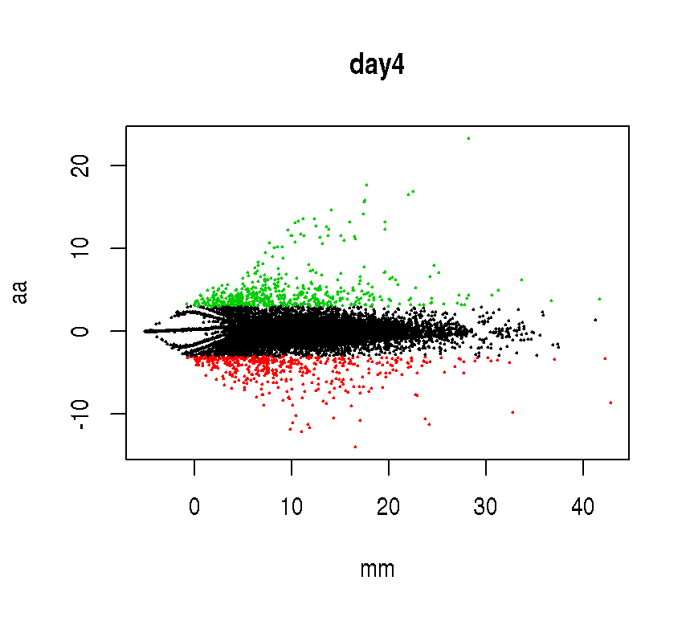

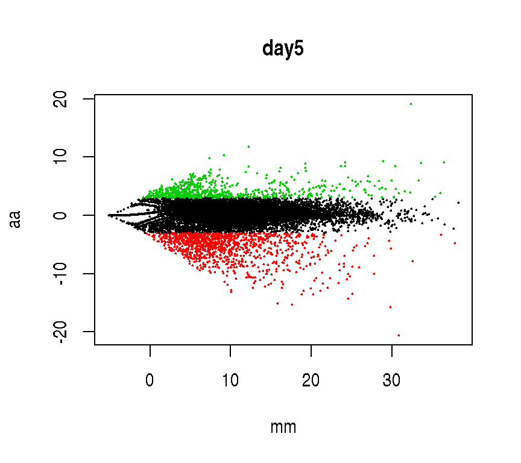

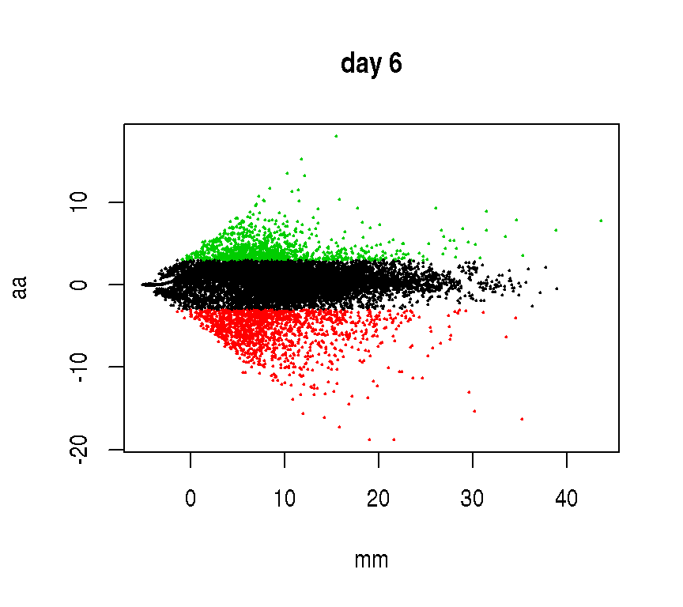